# Interactions

Tutorial 8: exercises and solutions

Dr Massimiliano Canzi

## Setup

```r
library(tidyverse)
library(broom)
library(simling)
```

## The data

In `agreement_attraction`, 40 participants read sentences like *The key to the cabinet(s) was/were rusty* while an eye tracker records their eye movements. The verb is either grammatical (*was*) or ungrammatical (*were*), and the noun before it, the attractor, is singular (*cabinet*) or plural (*cabinets*). `gaze_duration` is the time in ms that readers look at the verb the first time they reach it. It is `NA` when they skipped the verb.

```r
glimpse(agreement_attraction)
```

```
Rows: 1,280
Columns: 10
$ participant    <fct> P01, P01, P01, P01, P01, P01, P01, P01, P01, …
$ list           <int> 1, 1, 1, 1, 1, 1, 1, 1, 1, 1, 1, 1, 1, 1, 1, …
$ item           <fct> i01, i02, i03, i04, i05, i06, i07, i08, i09, …
$ grammaticality <fct> ungrammatical, ungrammatical, grammatical, gr…
$ attractor      <fct> singular, plural, singular, plural, singular,…
$ skipped        <int> 0, 0, 0, 0, 0, 0, 0, 0, 0, 0, 0, 0, 0, 0, 0, …
$ first_fixation <dbl> 398, 349, 135, 217, 229, 265, 237, 200, 549, …
$ gaze_duration  <dbl> 398, 349, 186, 217, 229, 265, 237, 200, 549, …
$ regression     <int> 0, 0, 0, 0, 0, 0, 0, 0, 0, 0, 0, 1, 0, 0, 0, …
$ total_time     <dbl> 687, 349, 186, 217, 361, 265, 237, 200, 950, …
```

Today’s question: does a plural attractor make an ungrammatical verb easier to read?

# 1. Two categorical predictors

## 1.1 Four cell means

Compute the mean `gaze_duration` in each of the four combinations of `grammaticality` and `attractor`, and save the result as `cells`. Use `na.rm = TRUE`, because skipped verbs have no gaze duration.

## 1.1 Solution

```r
cells <- agreement_attraction |>
  summarise(gaze = mean(gaze_duration, na.rm = TRUE), .by = c(grammaticality, attractor))
cells
```

```
# A tibble: 4 × 3
  grammaticality attractor  gaze
  <fct>          <fct>     <dbl>
1 ungrammatical  singular   307.
2 ungrammatical  plural     287.
3 grammatical    singular   272.
4 grammatical    plural     277.
```

## 1.2 An interaction plot

Plot the four means from `cells`, with `grammaticality` on the `x` axis and one colour and one line per `attractor` (`group = attractor`). Are the lines parallel?

## 1.2 Solution

```r
cells |>
  ggplot(aes(x = grammaticality, y = gaze, colour = attractor, group = attractor)) +
  geom_point(size = 4) +
  geom_line(linewidth = 1) +
  xlab("Verb") + ylab("Gaze duration (ms)") +
  theme(legend.position = "right")
```

## 1.2 Solution

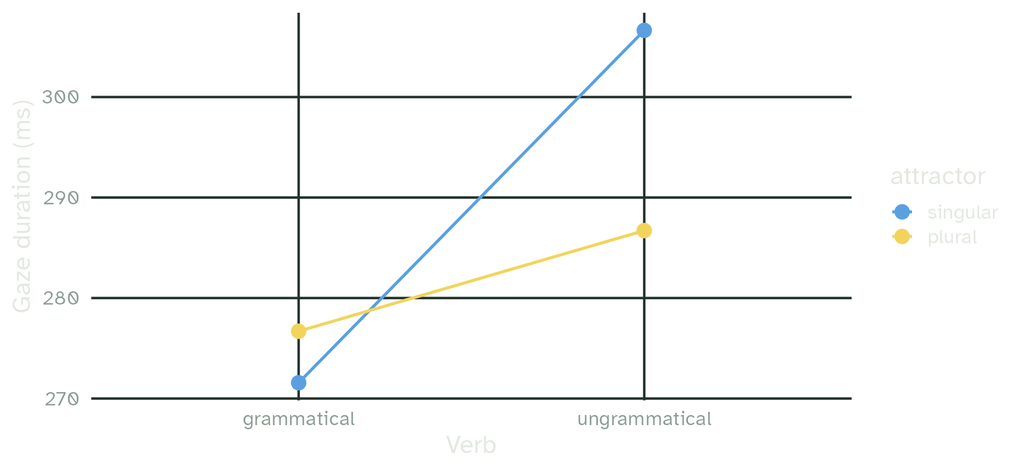

The lines are not parallel. Ungrammatical verbs are read more slowly, but much less so after a plural attractor.

## 1.3 The model

Fit a linear model of `gaze_duration` with `grammaticality`, `attractor` and their interaction, and print its coefficients. What are the reference levels?

## 1.3 Solution

```r
m <- lm(gaze_duration ~ grammaticality * attractor, data = agreement_attraction)
coef(m)
```

```
                                (Intercept)
                                 271.569395
                grammaticalityungrammatical
                                  35.065291
                            attractorplural
                                   5.126576
grammaticalityungrammatical:attractorplural
                                 -25.048027
```

The reference levels are `grammatical` and `singular`, the first level of each factor. The intercept is the mean gaze duration on a grammatical verb after a singular attractor.

## 1.4 Rebuild the cell means

Use the four coefficients to compute the predicted gaze duration in each of the four cells. Compare your numbers with `cells`.

## 1.4 Solution

```r
b <- coef(m)
c(grammatical_singular = b[[1]],
  ungrammatical_singular = b[[1]] + b[[2]],
  grammatical_plural = b[[1]] + b[[3]],
  ungrammatical_plural = b[[1]] + b[[2]] + b[[3]] + b[[4]])
```

```
  grammatical_singular ungrammatical_singular     grammatical_plural
              271.5694               306.6347               276.6960
  ungrammatical_plural
              286.7132
```

The four predictions are the four cell means. The interaction coefficient is only needed for the cell where both predictors differ from their reference level.

## 1.5 In words

Say in two sentences what the coefficient of `grammaticalityungrammatical` and the interaction coefficient mean.

## 1.5 Solution

After a singular attractor, an ungrammatical verb is read 35 ms more slowly than a grammatical one. After a plural attractor, this cost is 25 ms smaller, only 10 ms: the plural attractor makes *were* look less wrong.

# 2. A categorical and a continuous predictor

`lexical_decision_l2` has reaction times (`rt`, in ms) of 15 L1 and 15 L2 speakers of German to 40 words, with each word’s log10 frequency (`log_freq`).

## 2.1 Two groups, two lines

Plot `rt` against `log_freq`, with one colour and one regression line per `group`. Do frequent words help both groups equally?

## 2.1 Solution

```r
lexical_decision_l2 |>
  ggplot(aes(x = log_freq, y = rt, colour = group)) +
  geom_point(alpha = 0.3) +
  geom_smooth(method = "lm", se = FALSE) +
  xlab("log10 frequency") + ylab("Reaction time (ms)") +
  theme(legend.position = "right")
```

## 2.1 Solution

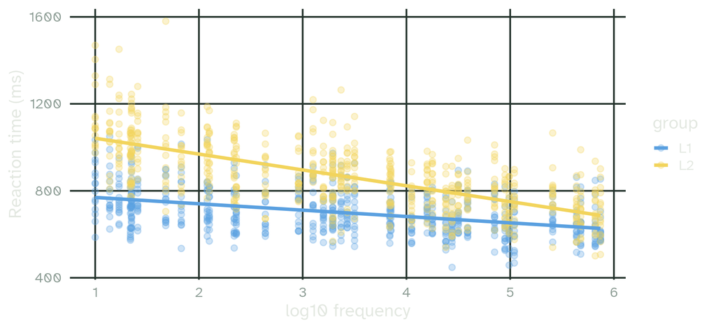

The line of the L2 speakers is steeper: they gain more from frequent words.

## 2.2 Centre and fit

Centre `log_freq` on its mean, in a new column `freq_c`. Fit a model of `rt` with `freq_c`, `group` and their interaction. What do the coefficients of `freq_c`, `groupL2` and the interaction mean?

## 2.2 Solution

```r
lex <- lexical_decision_l2 |>
  mutate(freq_c = log_freq - mean(log_freq))
m_lex <- lm(rt ~ freq_c * group, data = lex)
coef(m_lex)
```

```
   (Intercept)         freq_c        groupL2 freq_c:groupL2
     699.18167      -29.23611      167.13000      -43.62340
```

For L1 speakers, each log unit of frequency makes responses 29 ms faster. For a word of average frequency, L2 speakers are 167 ms slower than L1 speakers. For L2 speakers, the frequency effect is 44 ms larger: responses get 73 ms faster per log unit.

## 2.3 Bonus: without centring

Fit the same model with `log_freq` instead of `freq_c`. Which coefficient changes a lot, and why?

## 2.3 Solution

```r
coef(lm(rt ~ log_freq * group, data = lexical_decision_l2))
```

```
     (Intercept)         log_freq          groupL2 log_freq:groupL2
       798.83295        -29.23611        315.82034        -43.62340
```

The coefficient of `groupL2` changes: it is now the difference between the groups for a word with a log frequency of 0, far below the frequencies in the data. Where the lines are steeper, the groups are further apart, so this difference is larger than at the mean frequency. The slopes and the interaction stay the same.

# 3. Weekly assignment

Exercises 3.1 to 3.3 are this week’s assignment. Complete them at home, in a file started from the konstats template “Weekly assignment” (tutorial 1), and hand in the .Rmd file within a week.

In `acceptability`, 48 participants rate sentences on a scale from 1 (very bad) to 7 (very good). The sentences contain a long or a short dependency (`length`) between a *wh*-word and its gap, and the gap is inside an island or not (`structure`). Islands are structures out of which a dependency is hard to form, such as *whether* clauses.

## 3.1 Cell means and plot

Compute the mean `rating` in each combination of `length` and `structure`, and make an interaction plot with `length` on the `x` axis and one line per `structure`. Are the lines parallel?

## 3.2 The model

Fit a linear model of `rating` with `length`, `structure` and their interaction. Report each of the four coefficients in a sentence.

## 3.3 The island effect

An island effect means that long dependencies out of islands are worse than the two effects on their own predict. Compute, from the cell means, how much ratings drop from short to long dependencies in non-islands, and how much in islands. Which coefficient of your model is the difference between the two drops? Is there an island effect?

## Reading

This tutorial goes with chapter 8 of Winter (2019).

Winter, B. (2019). *Statistics for linguists: An introduction using R*. Routledge. https://doi.org/10.4324/9781315165547

## Slides and exercises

[figure not shown]

These slides

mcanzi.de/statistics/tutorials/08_interactions.html

Exercise sheet (R Markdown)

mcanzi.de/statistics/tutorials/08_interactions.Rmd